# Fifa Ratings: Multiple Linear Regressions Model

By Tej Seth and Projeet Mukherjee

## I. Introduction

Alex on Kaggle has compiled datasets from sofifa.com relating to the FIFA22 soccer video game made by EA Sports. The dataset we chose to analyze is the `players_fifa22.csv` dataset. The overall dataset has 19,260 rows and 90 columns. It has a mix of different types of variables such as a player’s cateogirical variables like name, country, club team, position, etc. as well as over 70 quantative variables including their overall rating and their shooting rating, how much their contract is worth and more.

In FIFA, the most important thing for a player’s performance is their `Overall`. Because of that, we will make that the response variable and try to model is based on quantitative variables such as `Age`, `Height`, `ShootingTotal`, `PassingTotal`, `DefendingTotal`, `PhysicalityTotal` and `ValueEUR` and a categorical variable such as `BestPosition`. These variables provide a good base for creating a multiple linear regressions model to predict a player’s overall rating in the game.

```r
library(tidyverse)
library(ggthemes)
options(scipen = 9999)

theme_reach <- function() {
  theme_fivethirtyeight() +
    theme(
      legend.position = "none",
      plot.title = element_text(size = 22, hjust = 0.5, face = "bold"),
      plot.subtitle = element_text(size = 18, hjust = 0.5),
      axis.title.x = element_text(size=18),
      axis.title.y = element_text(size=18),
      axis.text = element_text(size = 14),
      strip.text = element_text(size = 16, face = "bold"),
      legend.text = element_text(size = 14),
    )
}

fifa_22 <- read_csv(url("https://raw.githubusercontent.com/tejseth/stats-401-project/master/players_fifa22.csv"))
```

## II. Early Data Analysis (EDA)

With a dataset of this magnitude, we felt like it was important to select just the variables we needed. On top of that, since 19,260 rows is a lot of data to work with, we randomly selected a quarter of it (4,815 rows) so that it’s easier to see the correlations and use.

```r
fifa_small <- fifa_22 %>%
  select(FullName, Age, Height, Weight, PhotoUrl, Overall, BestPosition, ValueEUR,
         ShootingTotal, PassingTotal, DefendingTotal, PhysicalityTotal)

fifa_smallest <- sample_n(fifa_small, 4815)
```

Now that we had the parameters of the dataset we wanted, we can do some early data analysis on it by looking at distributions by using histograms to see if the data is normally distributed or needs to be log transformed in the model.

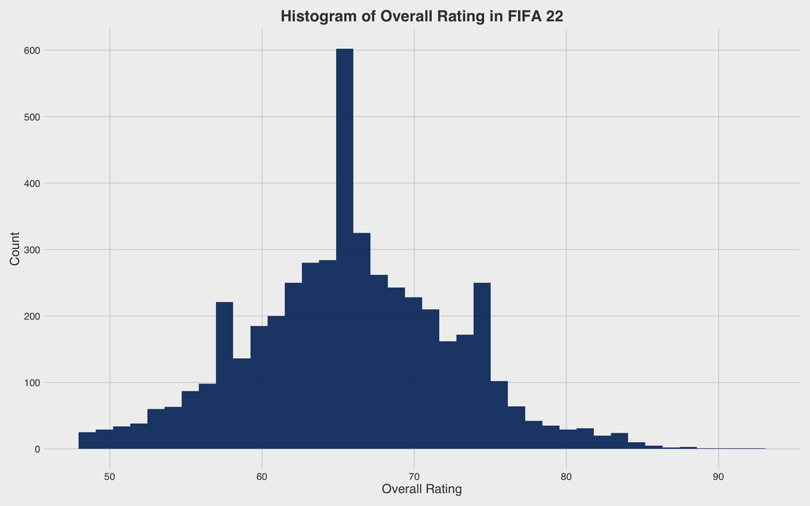

```r
fifa_smallest %>%
  ggplot(aes(x = Overall)) +
  geom_histogram(fill = "#012e67", alpha = 0.9, bins = 40) +
  scale_color_identity() +
  theme_reach() +
  labs(x = "Overall Rating",
       y = "Count",
       title = "Histogram of Overall Rating in FIFA 22") +
  scale_x_continuous(breaks = scales::pretty_breaks()) +
  scale_y_continuous(breaks = scales::pretty_breaks())
```

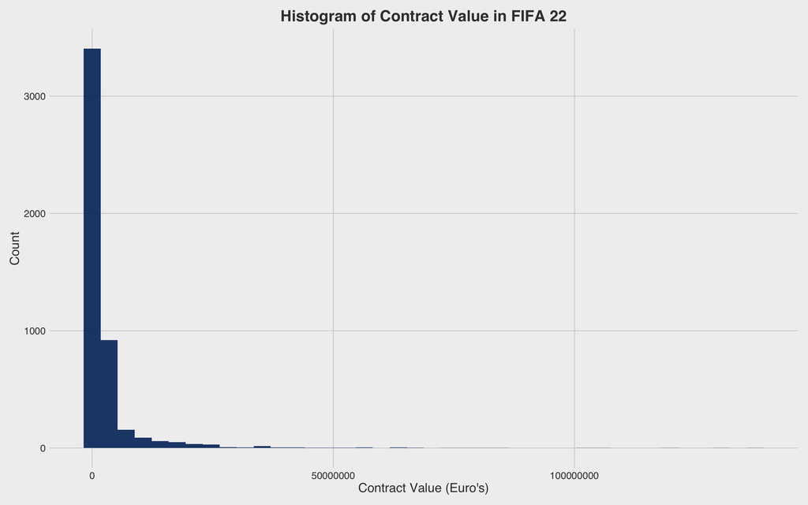

```r
fifa_smallest %>%
  ggplot(aes(x = ValueEUR)) +
  geom_histogram(fill = "#012e67", alpha = 0.9, bins = 40) +
  scale_color_identity() +
  theme_reach() +
  labs(x = "Contract Value (Euro's)",
       y = "Count",
       title = "Histogram of Contract Value in FIFA 22") +
  scale_x_continuous(breaks = scales::pretty_breaks()) +
  scale_y_continuous(breaks = scales::pretty_breaks())
```

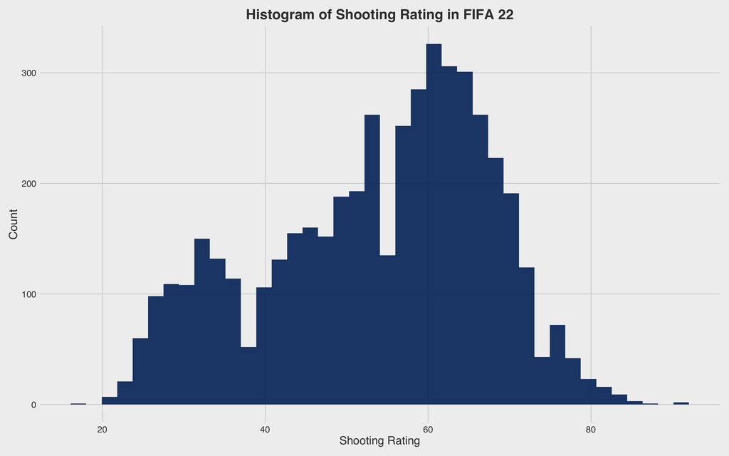

```r
fifa_smallest %>%
  ggplot(aes(x = ShootingTotal)) +
  geom_histogram(fill = "#012e67", alpha = 0.9, bins = 40) +
  scale_color_identity() +
  theme_reach() +
  labs(x = "Shooting Rating",
       y = "Count",
       title = "Histogram of Shooting Rating in FIFA 22") +
  scale_x_continuous(breaks = scales::pretty_breaks()) +
  scale_y_continuous(breaks = scales::pretty_breaks())
```

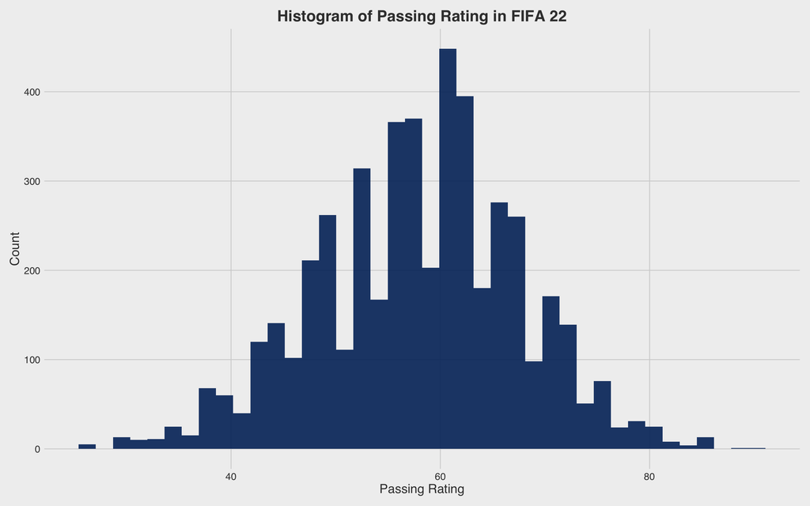

```r
fifa_smallest %>%
  ggplot(aes(x = PassingTotal)) +
  geom_histogram(fill = "#012e67", alpha = 0.9, bins = 40) +
  scale_color_identity() +
  theme_reach() +
  labs(x = "Passing Rating",
       y = "Count",
       title = "Histogram of Passing Rating in FIFA 22") +
  scale_x_continuous(breaks = scales::pretty_breaks()) +
  scale_y_continuous(breaks = scales::pretty_breaks())
```

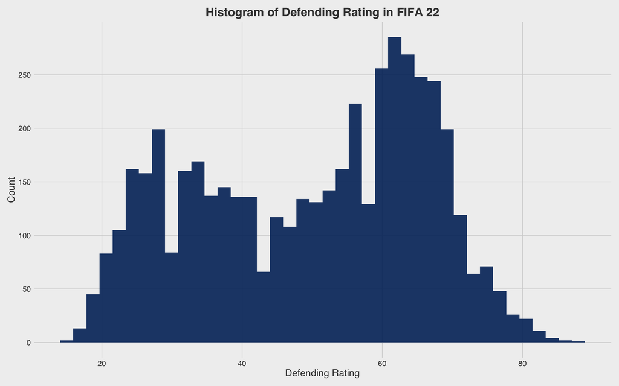

```r
fifa_smallest %>%
  ggplot(aes(x = DefendingTotal)) +
  geom_histogram(fill = "#012e67", alpha = 0.9, bins = 40) +
  scale_color_identity() +
  theme_reach() +
  labs(x = "Defending Rating",
       y = "Count",
       title = "Histogram of Defending Rating in FIFA 22") +
  scale_x_continuous(breaks = scales::pretty_breaks()) +
  scale_y_continuous(breaks = scales::pretty_breaks())
```

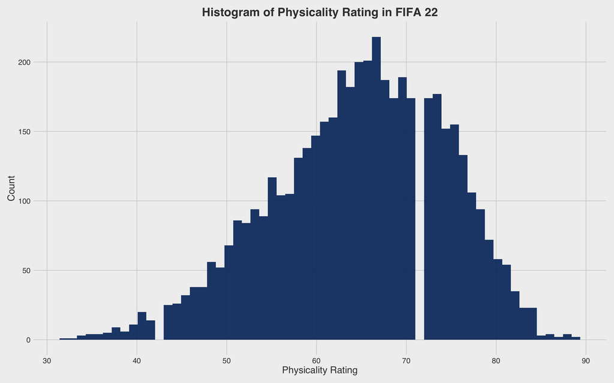

```r
fifa_smallest %>%
  ggplot(aes(x = PhysicalityTotal)) +
  geom_histogram(fill = "#012e67", alpha = 0.9, bins = 60) +
  scale_color_identity() +
  theme_reach() +
  labs(x = "Physicality Rating",
       y = "Count",
       title = "Histogram of Physicality Rating in FIFA 22") +
  scale_x_continuous(breaks = scales::pretty_breaks()) +
  scale_y_continuous(breaks = scales::pretty_breaks())
```